# AI Coursework 2 Final Submission, 23050386 Prashanna Sthapit

## Project Overview

This project aims to predict emergency department readmission within 6 months for discharged heart failure patients using three machine learning models:

1. **Logistic Regression** - A baseline linear model
2. **Random Forest** - An ensemble tree-based model
3. **XGBoost** - A gradient boosting algorithm

We will perform a comparative analysis of these models to determine the most effective approach for this prediction task.

## 1. Install and Import Required Libraries

```python
%pip install pandas numpy matplotlib seaborn scikit-learn xgboost
```

```python
# Data manipulation and analysis
import pandas as pd
import numpy as np

# Visualization
import matplotlib.pyplot as plt
import seaborn as sns

# Preprocessing
from sklearn.model_selection import train_test_split, cross_val_score, StratifiedKFold
from sklearn.preprocessing import StandardScaler, LabelEncoder

# Models
from sklearn.linear_model import LogisticRegression
from sklearn.ensemble import RandomForestClassifier
from xgboost import XGBClassifier

# Evaluation metrics
from sklearn.metrics import (accuracy_score, precision_score, recall_score,
                             f1_score, roc_auc_score, confusion_matrix,
                             classification_report, roc_curve)

# Suppress warnings
import warnings
warnings.filterwarnings('ignore')

# Set display options
pd.set_option('display.max_columns', None)
plt.style.use('seaborn-v0_8-whitegrid')

print("All libraries imported successfully!")
```

```
All libraries imported successfully!
```

## 2. Load and Explore the Data

```python
# Load the main dataset
df = pd.read_csv('dataset/dat.csv', index_col=0)
```

```python
# Display basic information
print("=" * 20)
print("  DATASET OVERVIEW")
print("=" * 20)
print(f"\nDataset Shape: {df.shape[0]} rows, {df.shape[1]} columns")
print(f"\nFirst 5 rows:")
df.head()
```

```
====================
  DATASET OVERVIEW
====================

Dataset Shape: 2008 rows, 166 columns

First 5 rows:
```

|  | inpatient.number | DestinationDischarge | admission.ward | admission.way | occupation | discharge.department | visit.times | gender | body.temperature | pulse | respiration | systolic.blood.pressure | diastolic.blood.pressure | map | weight | height | BMI | type.of.heart.failure | NYHA.cardiac.function.classification | Killip.grade | myocardial.infarction | congestive.heart.failure | peripheral.vascular.disease | cerebrovascular.disease | dementia | Chronic.obstructive.pulmonary.disease | connective.tissue.disease | peptic.ulcer.disease | diabetes | … |
| --- | --- | --- | --- | --- | --- | --- | --- | --- | --- | --- | --- | --- | --- | --- | --- | --- | --- | --- | --- | --- | --- | --- | --- | --- | --- | --- | --- | --- | --- | --- |
| 1 | 857781 | Home | Cardiology | NonEmergency | UrbanResident | Cardiology | 1 | Male | 36.7 | 87 | 19 | 102 | 64 | 76.666667 | 50.0 | 1.64 | 18.590125 | Both | III | III | 0 | 0 | 0 | 0 | 0 | 1 | 0 | 0.0 | 1 | … |
| 2 | 743087 | Home | Cardiology | NonEmergency | UrbanResident | Cardiology | 1 | Female | 36.8 | 95 | 18 | 150 | 70 | 96.666667 | 51.0 | 1.63 | 19.195303 | Both | III | I | 0 | 0 | 0 | 0 | 0 | 0 | 0 | 0.0 | 0 | … |
| 3 | 866418 | Home | Cardiology | NonEmergency | farmer | Cardiology | 2 | Male | 36.5 | 98 | 18 | 102 | 67 | 78.666667 | 70.0 | 1.70 | 24.221453 | Both | II | II | 0 | 0 | 0 | 0 | 0 | 0 | 0 | 0.0 | 0 | … |
| 4 | 775928 | Home | Cardiology | Emergency | UrbanResident | Cardiology | 1 | Male | 36.0 | 73 | 19 | 110 | 74 | 86.000000 | 65.0 | 1.70 | 22.491349 | Both | III | II | 0 | 0 | 0 | 0 | 0 | 1 | 0 | 0.0 | 0 | … |
| 5 | 810128 | Home | Cardiology | NonEmergency | UrbanResident | Cardiology | 1 | Female | 35.0 | 88 | 19 | 134 | 62 | 86.000000 | 76.0 | 1.55 | 31.633715 | Both | III | II | 0 | 0 | 0 | 0 | 0 | 0 | 0 | 0.0 | 0 | … |

```python
# Display data types and non-null counts
print("\nData Types and Non-Null Counts:")
print("-" * 60)
df.info()
```

```
Data Types and Non-Null Counts:
------------------------------------------------------------
<class 'pandas.core.frame.DataFrame'>
Index: 2008 entries, 1 to 2008
Columns: 166 entries, inpatient.number to ageCat
dtypes: float64(119), int64(32), object(15)
memory usage: 2.6+ MB
```

```python
# Statistical summary
print("\nStatistical Summary:")
print("-" * 60)
df.describe()
```

```
Statistical Summary:
------------------------------------------------------------
```

|  | inpatient.number | visit.times | body.temperature | pulse | respiration | systolic.blood.pressure | diastolic.blood.pressure | map | weight | height | BMI | myocardial.infarction | congestive.heart.failure | peripheral.vascular.disease | cerebrovascular.disease | dementia | Chronic.obstructive.pulmonary.disease | connective.tissue.disease | peptic.ulcer.disease | diabetes | moderate.to.severe.chronic.kidney.disease | hemiplegia | leukemia | malignant.lymphoma | solid.tumor | liver.disease | AIDS | CCI.score | eye.opening | … |
| --- | --- | --- | --- | --- | --- | --- | --- | --- | --- | --- | --- | --- | --- | --- | --- | --- | --- | --- | --- | --- | --- | --- | --- | --- | --- | --- | --- | --- | --- | --- |
| count | 2008.000000 | 2008.000000 | 2008.000000 | 2008.000000 | 2008.000000 | 2008.000000 | 2008.000000 | 2008.000000 | 2008.000000 | 2008.000000 | 2008.000000 | 2008.000000 | 2008.000000 | 2008.000000 | 2008.000000 | 2008.000000 | 2008.000000 | 2008.000000 | 2006.000000 | 2008.000000 | 2006.000000 | 2008.000000 | 2008.0 | 2008.000000 | 2008.000000 | 2007.000000 | 2008.000000 | 2003.000000 | 2008.000000 | … |
| mean | 797747.542829 | 1.092629 | 36.416484 | 85.235060 | 19.085657 | 131.056773 | 76.573207 | 94.734396 | 52.483715 | 1.567869 | 21.791398 | 0.071215 | 0.932271 | 0.050299 | 0.074701 | 0.057271 | 0.116036 | 0.001992 | 0.022433 | 0.232072 | 0.236291 | 0.005976 | 0.0 | 0.000498 | 0.019422 | 0.041854 | 0.001992 | 1.861707 | 3.963645 | … |
| std | 41127.801740 | 0.365946 | 0.439529 | 21.539214 | 1.737546 | 24.741670 | 14.461247 | 16.323762 | 10.895935 | 0.096138 | 13.645009 | 0.257248 | 0.251343 | 0.218615 | 0.262974 | 0.232417 | 0.320348 | 0.044599 | 0.148123 | 0.422260 | 0.424909 | 0.077093 | 0.0 | 0.022316 | 0.138038 | 0.200304 | 0.044599 | 0.961469 | 0.282654 | … |
| min | 722128.000000 | 1.000000 | 35.000000 | 0.000000 | 0.000000 | 0.000000 | 0.000000 | 0.000000 | 0.000000 | 0.350000 | 0.000000 | 0.000000 | 0.000000 | 0.000000 | 0.000000 | 0.000000 | 0.000000 | 0.000000 | 0.000000 | 0.000000 | 0.000000 | 0.000000 | 0.0 | 0.000000 | 0.000000 | 0.000000 | 0.000000 | 0.000000 | 1.000000 | … |
| 25% | 763164.500000 | 1.000000 | 36.200000 | 70.000000 | 18.000000 | 113.000000 | 65.000000 | 83.333333 | 45.000000 | 1.500000 | 18.491124 | 0.000000 | 1.000000 | 0.000000 | 0.000000 | 0.000000 | 0.000000 | 0.000000 | 0.000000 | 0.000000 | 0.000000 | 0.000000 | 0.0 | 0.000000 | 0.000000 | 0.000000 | 0.000000 | 1.000000 | 4.000000 | … |
| 50% | 798758.000000 | 1.000000 | 36.300000 | 82.000000 | 19.000000 | 130.000000 | 76.000000 | 93.333333 | 50.000000 | 1.560000 | 20.761246 | 0.000000 | 1.000000 | 0.000000 | 0.000000 | 0.000000 | 0.000000 | 0.000000 | 0.000000 | 0.000000 | 0.000000 | 0.000000 | 0.0 | 0.000000 | 0.000000 | 0.000000 | 0.000000 | 2.000000 | 4.000000 | … |
| 75% | 829399.750000 | 1.000000 | 36.500000 | 98.000000 | 19.000000 | 146.250000 | 85.000000 | 104.666667 | 60.000000 | 1.620000 | 23.437500 | 0.000000 | 1.000000 | 0.000000 | 0.000000 | 0.000000 | 0.000000 | 0.000000 | 0.000000 | 0.000000 | 0.000000 | 0.000000 | 0.0 | 0.000000 | 0.000000 | 0.000000 | 0.000000 | 2.000000 | 4.000000 | … |
| max | 905720.000000 | 5.000000 | 42.000000 | 198.000000 | 36.000000 | 252.000000 | 146.000000 | 181.333333 | 115.000000 | 1.830000 | 404.081633 | 1.000000 | 1.000000 | 1.000000 | 1.000000 | 1.000000 | 1.000000 | 1.000000 | 1.000000 | 1.000000 | 1.000000 | 1.000000 | 0.0 | 1.000000 | 1.000000 | 1.000000 | 1.000000 | 6.000000 | 4.000000 | … |

### 2.1 Target Variable Analysis

Our target variable is `return.to.emergency.department.within.6.months` which indicates whether a patient returned to the emergency department within 6 months of discharge.

```
Target Variable Distribution:
----------------------------------------
return.to.emergency.department.within.6.months
0.0    1232
1.0     775
Name: count, dtype: int64

Class Balance:
return.to.emergency.department.within.6.months
0.0    61.39
1.0    38.61
Name: proportion, dtype: float64
```

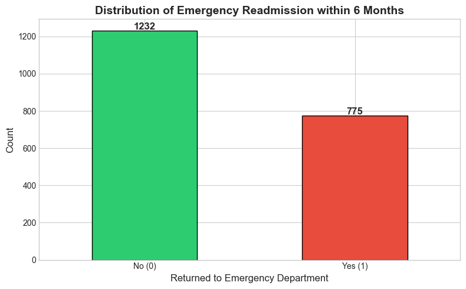

```python
# Define target variable
target_col = 'return.to.emergency.department.within.6.months'

# Check target variable distribution
print("Target Variable Distribution:")
print("-" * 40)
print(df[target_col].value_counts())
print(f"\nClass Balance:")
print(df[target_col].value_counts(normalize=True).round(4) * 100)

# Visualize target distribution
fig, ax = plt.subplots(figsize=(8, 5))
colors = ['#2ecc71', '#e74c3c']
df[target_col].value_counts().plot(kind='bar', color=colors, edgecolor='black', ax=ax)
ax.set_title('Distribution of Emergency Readmission within 6 Months', fontsize=14, fontweight='bold')
ax.set_xlabel('Returned to Emergency Department', fontsize=12)
ax.set_ylabel('Count', fontsize=12)
ax.set_xticklabels(['No (0)', 'Yes (1)'], rotation=0)

# Add value labels on bars
for i, v in enumerate(df[target_col].value_counts().values):
    ax.text(i, v + 5, str(v), ha='center', fontweight='bold', fontsize=12)

plt.tight_layout()
plt.show()
```

### 2.2 Missing Values Analysis

**Important Note:** In medical datasets, missing values often carry meaningful information. A null value for a lab test (e.g., cholinesterase) may indicate that the test was not ordered, which itself can be clinically significant. Rather than treating these as "missing data," we should consider them as "deliberately not recorded" or "not applicable" - preserving this information through indicator features.

```
Columns with Missing Values: 116
------------------------------------------------------------
                                              Missing Count  \
cholinesterase                                         2008
respiratory.support.                                   1966
time.of.death..days.from.admission.                    1964
homocysteine                                           1862
apolipoprotein.A                                       1832
apolipoprotein.B                                       1832
lipoprotein                                            1832
tricuspid.valve.return.pressure                        1826
erythrocyte.sedimentation.rate                         1701
EA                                                     1615
myoglobin                                              1610
Inorganic.Phosphorus                                   1601
serum.magnesium                                        1601
mitral.valve.AMS                                       1458
glutamic.oxaliplatin                                   1416
LVEF                                                   1373
tricuspid.valve.return.velocity                        1218
time.to.emergency.department.within.6.months           1111
re.admission.time..days.from.admission.                1107
high.sensitivity.protein                               1067

                                              Missing Percentage
cholinesterase                                            100.00
respiratory.support.                                       97.91
time.of.death..days.from.admission.                        97.81
homocysteine                                               92.73
apolipoprotein.A                                           91.24
apolipoprotein.B                                           91.24
lipoprotein                                                91.24
tricuspid.valve.return.pressure                            90.94
erythrocyte.sedimentation.rate                             84.71
EA                                                         80.43
myoglobin                                                  80.18
Inorganic.Phosphorus                                       79.73
serum.magnesium                                            79.73
mitral.valve.AMS                                           72.61
glutamic.oxaliplatin                                       70.52
LVEF                                                       68.38
tricuspid.valve.return.velocity                            60.66
time.to.emergency.department.within.6.months               55.33
re.admission.time..days.from.admission.                    55.13
high.sensitivity.protein                                   53.14
```

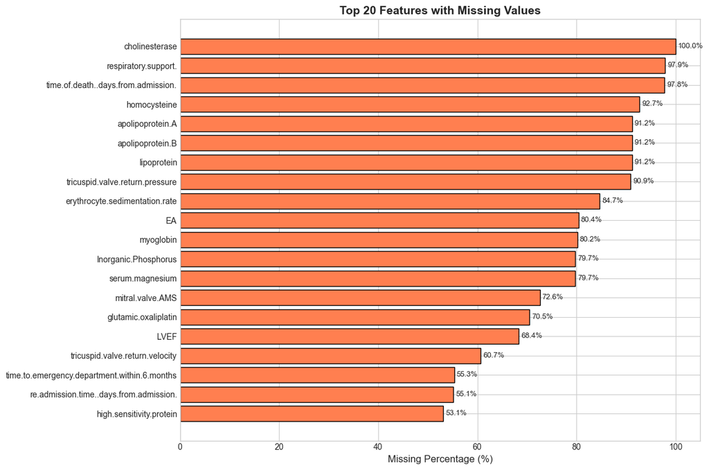

```python
# Calculate missing values
missing_data = pd.DataFrame({
    'Missing Count': df.isnull().sum(),
    'Missing Percentage': (df.isnull().sum() / len(df) * 100).round(2)
})
missing_data = missing_data[missing_data['Missing Count'] > 0].sort_values('Missing Percentage', ascending=False)

print(f"Columns with Missing Values: {len(missing_data)}")
print("-" * 60)
print(missing_data.head(20))

# Visualize missing values (top 20)
if len(missing_data) > 0:
    fig, ax = plt.subplots(figsize=(12, 8))
    top_missing = missing_data.head(20)
    bars = ax.barh(range(len(top_missing)), top_missing['Missing Percentage'], color='coral', edgecolor='black')
    ax.set_yticks(range(len(top_missing)))
    ax.set_yticklabels(top_missing.index)
    ax.set_xlabel('Missing Percentage (%)', fontsize=12)
    ax.set_title('Top 20 Features with Missing Values', fontsize=14, fontweight='bold')
    ax.invert_yaxis()

    # Add percentage labels
    for i, v in enumerate(top_missing['Missing Percentage']):
        ax.text(v + 0.5, i, f'{v:.1f}%', va='center', fontsize=9)

    plt.tight_layout()
    plt.show()
```

## 3. Data Preprocessing and Cleaning

```python
# Create a copy for preprocessing
df_clean = df.copy()

# Identify column types
categorical_cols = df_clean.select_dtypes(include=['object']).columns.tolist()
numerical_cols = df_clean.select_dtypes(include=['int64', 'float64']).columns.tolist()

print(f"Categorical columns: {len(categorical_cols)}")
print(categorical_cols)
print(f"\nNumerical columns: {len(numerical_cols)}")
```

```
Categorical columns: 15
['DestinationDischarge', 'admission.ward', 'admission.way', 'occupation', 'discharge.department', 'gender', 'type.of.heart.failure', 'NYHA.cardiac.function.classification', 'Killip.grade', 'type.II.respiratory.failure', 'consciousness', 'respiratory.support.', 'oxygen.inhalation', 'outcome.during.ho…

Numerical columns: 151
```

### 3.1 Feature Selection

We will exclude:

- Identifier columns (inpatient.number)
- Target-related/leakage columns (other outcome variables, time-based outcomes)

**Note:** We are NOT excluding columns based on null percentage because null values are meaningful in this medical dataset (indicating tests not performed).

```python
# Columns to exclude (identifiers, other outcomes, time-related leakage columns)
exclude_cols = [
    'inpatient.number',  # Identifier
    # Outcome variables (potential data leakage)
    'outcome.during.hospitalization',
    'death.within.28.days',
    're.admission.within.28.days',
    'death.within.3.months',
    're.admission.within.3.months',
    'death.within.6.months',
    're.admission.within.6.months',
    'time.of.death..days.from.admission.',
    're.admission.time..days.from.admission.',
    'time.to.emergency.department.within.6.months',
    # Target variable (will be handled separately)
    'return.to.emergency.department.within.6.months'
]

# NOTE: We are NOT removing columns with high null percentages because:
# - Null values are MEANINGFUL in this medical dataset (they indicate tests not performed)
# - The absence of a test can itself be predictive of outcomes
# - We will create indicator features to capture this information

print("Columns to exclude (identifiers and outcome-related):")
for col in exclude_cols:
    print(f"  - {col}")

# Show columns with high null percentages (for reference only - NOT excluding them)
high_null_cols = missing_data[missing_data['Missing Percentage'] > 50].index.tolist()
print(f"\nColumns with >50% null values (KEEPING these - nulls are meaningful):")
for col in high_null_cols:
    pct = missing_data.loc[col, 'Missing Percentage']
    print(f"  - {col}: {pct:.1f}% null")

all_exclude_cols = exclude_cols  # Only exclude identifiers and outcomes
print(f"\nTotal columns to exclude: {len(all_exclude_cols)}")
```

```
Columns to exclude (identifiers and outcome-related):
  - inpatient.number
  - outcome.during.hospitalization
  - death.within.28.days
  - re.admission.within.28.days
  - death.within.3.months
  - re.admission.within.3.months
  - death.within.6.months
  - re.admission.within.6.months
  - time.of.death..days.from.admission.
  - re.admission.time..days.from.admission.
  - time.to.emergency.department.within.6.months
  - return.to.emergency.department.within.6.months

Columns with >50% null values (KEEPING these - nulls are meaningful):
  - cholinesterase: 100.0% null
  - respiratory.support.: 97.9% null
  - time.of.death..days.from.admission.: 97.8% null
  - homocysteine: 92.7% null
  - apolipoprotein.A: 91.2% null
  - apolipoprotein.B: 91.2% null
  - lipoprotein: 91.2% null
  - tricuspid.valve.return.pressure: 90.9% null
  - erythrocyte.sedimentation.rate: 84.7% null
  - EA: 80.4% null
  - myoglobin: 80.2% null
  - Inorganic.Phosphorus: 79.7% null
  - serum.magnesium: 79.7% null
  - mitral.valve.AMS: 72.6% null
  - glutamic.oxaliplatin: 70.5% null
  - LVEF: 68.4% null
  - tricuspid.valve.return.velocity: 60.7% null
  - time.to.emergency.department.within.6.months: 55.3% null
  - re.admission.time..days.from.admission.: 55.1% null
  - high.sensitivity.protein: 53.1% null
  - mitral.valve.EMS: 51.2% null
  - methemoglobin: 50.6% null
  - hematocrit.blood.gas: 50.6% null
  - reduced.hemoglobin: 50.6% null
  - carboxyhemoglobin: 50.6% null
  - oxyhemoglobin: 50.6% null
  - total.hemoglobin: 50.6% null
  - standard.bicarbonate: 50.5% null
  - measured.residual.base: 50.5% null
  - partial.pressure.of.carbon.dioxide: 50.5% null
  - standard.residual.base: 50.5% null
  - potassium.ion: 50.5% null
  - chloride.ion: 50.5% null
  - pH: 50.5% null
  - sodium.ion: 50.5% null
  - glucose.blood.gas: 50.5% null
  - lactate: 50.5% null
  - measured.bicarbonate: 50.5% null
  - body.temperature.blood.gas: 50.5% null
  - oxygen.saturation: 50.5% null
  - partial.oxygen.pressure: 50.5% null
  - anion.gap: 50.5% null
  - free.calcium: 50.5% null
  - total.carbon.dioxide: 50.5% null

Total columns to exclude: 12
```

```python
# Select features for modeling
feature_cols = [col for col in df_clean.columns if col not in all_exclude_cols]

# Prepare feature matrix and target
X = df_clean[feature_cols].copy()
y = df_clean[target_col].copy()

print(f"Feature matrix shape: {X.shape}")
print(f"Target shape: {y.shape}")
print(f"\nSelected features: {len(feature_cols)}")
```

```
Feature matrix shape: (2008, 154)
Target shape: (2008,)

Selected features: 154
```

### 3.2 Handle Categorical Variables

```python
# Identify categorical columns in features
cat_features = X.select_dtypes(include=['object']).columns.tolist()
num_features = X.select_dtypes(include=['int64', 'float64']).columns.tolist()

print(f"Categorical features: {len(cat_features)}")
for col in cat_features:
    print(f"  {col}: {X[col].nunique()} unique values")
    print(f"    Values: {X[col].unique()[:10]}...")  # Show first 10 unique values
```

```
Categorical features: 14
  DestinationDischarge: 4 unique values
    Values: ['Home' 'HealthcareFacility' 'Unknown' 'Died']...
  admission.ward: 4 unique values
    Values: ['Cardiology' 'GeneralWard' 'ICU' 'Others']...
  admission.way: 2 unique values
    Values: ['NonEmergency' 'Emergency']...
  occupation: 5 unique values
    Values: ['UrbanResident' 'farmer' 'worker' 'Others' 'Officer' nan]...
  discharge.department: 4 unique values
    Values: ['Cardiology' 'Others' 'GeneralWard' 'ICU']...
  gender: 2 unique values
    Values: ['Male' 'Female']...
  type.of.heart.failure: 3 unique values
    Values: ['Both' 'Right' 'Left']...
  NYHA.cardiac.function.classification: 3 unique values
    Values: ['III' 'II' 'IV']...
  Killip.grade: 4 unique values
    Values: ['III' 'I' 'II' 'IV']...
  type.II.respiratory.failure: 2 unique values
    Values: ['NonTypeII' 'TypeII']...
  consciousness: 4 unique values
    Values: ['Clear' 'ResponsiveToPain' 'ResponsiveToSound' 'Nonresponsive']...
  respiratory.support.: 2 unique values
    Values: [nan 'NIMV' 'IMV']...
  oxygen.inhalation: 2 unique values
    Values: ['OxygenTherapy' 'AmbientAir']...
  ageCat: 8 unique values
    Values: ['(69,79]' '(59,69]' '(79,89]' '(49,59]' '(89,110]' '(29,39]' '(39,49]'
 '(21,29]']...
```

```python
# Encode categorical variables using Label Encoding for ordinal and One-Hot for nominal
# Store label encoders for later use
label_encoders = {}

# Define which categorical columns should be label encoded vs one-hot encoded
# Binary and ordinal categories - Label Encode
label_encode_cols = ['gender', 'admission.way', 'type.II.respiratory.failure',
                     'consciousness', 'respiratory.support.', 'oxygen.inhalation']

# Nominal categories with few values - One-Hot Encode
onehot_encode_cols = [col for col in cat_features if col not in label_encode_cols]

print("Label encoding columns:", label_encode_cols)
print("One-hot encoding columns:", onehot_encode_cols)

# Apply Label Encoding
for col in label_encode_cols:
    if col in X.columns:
        le = LabelEncoder()
        # Handle missing values by filling with a placeholder first
        X[col] = X[col].fillna('Unknown')
        X[col] = le.fit_transform(X[col].astype(str))
        label_encoders[col] = le
        print(f"Label encoded {col}: {dict(zip(le.classes_, range(len(le.classes_))))}")
```

```
Label encoding columns: ['gender', 'admission.way', 'type.II.respiratory.failure', 'consciousness', 'respiratory.support.', 'oxygen.inhalation']
One-hot encoding columns: ['DestinationDischarge', 'admission.ward', 'occupation', 'discharge.department', 'type.of.heart.failure', 'NYHA.cardiac.function.classification', 'Killip.grade', 'ageCat']
Label encoded gender: {'Female': 0, 'Male': 1}
Label encoded admission.way: {'Emergency': 0, 'NonEmergency': 1}
Label encoded type.II.respiratory.failure: {'NonTypeII': 0, 'TypeII': 1}
Label encoded consciousness: {'Clear': 0, 'Nonresponsive': 1, 'ResponsiveToPain': 2, 'ResponsiveToSound': 3}
Label encoded respiratory.support.: {'IMV': 0, 'NIMV': 1, 'Unknown': 2}
Label encoded oxygen.inhalation: {'AmbientAir': 0, 'OxygenTherapy': 1}
```

```python
# Apply One-Hot Encoding for nominal categorical variables
if onehot_encode_cols:
    # Fill missing values before encoding
    for col in onehot_encode_cols:
        if col in X.columns:
            X[col] = X[col].fillna('Unknown')

    X = pd.get_dummies(X, columns=onehot_encode_cols, drop_first=True, dtype=int)
    print(f"\nAfter one-hot encoding, feature matrix shape: {X.shape}")
```

```
After one-hot encoding, feature matrix shape: (2008, 174)
```

### 3.3 Handle Null Values in Numerical Features

**Important:** In this medical dataset, null values are not "missing" in the traditional sense - they are deliberate nulls that carry meaning. For example:

- A null value for a lab test may indicate the test was not performed (perhaps the patient didn't need it)
- This absence of a test can itself be predictive of outcomes

**Strategy:**

1. Create binary indicator features (`_is_null`) to preserve the information that a value was null
2. Fill the original null values with 0 (neutral value) to allow model computation

```python
# Check columns with null values
remaining_missing = X.isnull().sum()
cols_with_nulls = remaining_missing[remaining_missing > 0]
print(f"Columns with null values: {len(cols_with_nulls)}")
print(f"\nThese nulls are MEANINGFUL - they indicate tests not performed or conditions not assessed.")

# Create indicator features for null values (to preserve the meaningful information)
print("\nCreating indicator features for null values...")
null_indicator_cols = []

for col in cols_with_nulls.index:
    null_col_name = f"{col}_is_null"
    X[null_col_name] = X[col].isnull().astype(int)
    null_indicator_cols.append(null_col_name)

print(f"Created {len(null_indicator_cols)} null indicator features")

# Fill null values with 0 (neutral value) - the indicator feature preserves the information
X_imputed = X.fillna(0)

# Clean column names to remove special characters that XGBoost doesn't allow
# XGBoost doesn't allow [, ], or < in feature names
X_imputed.columns = X_imputed.columns.str.replace(r'[\[\]<>]', '_', regex=True)
X_imputed.columns = X_imputed.columns.str.replace(r'\s+', '_', regex=True)

# Verify no null values remain
print(f"\nNull values after processing: {X_imputed.isnull().sum().sum()}")
print(f"Final feature matrix shape: {X_imputed.shape}")
print(f"\nNote: Original null information is preserved in {len(null_indicator_cols)} indicator columns")
```

```
Columns with null values: 110

These nulls are MEANINGFUL - they indicate tests not performed or conditions not assessed.

Creating indicator features for null values...
Created 110 null indicator features

Null values after processing: 0
Final feature matrix shape: (2008, 284)

Note: Original null information is preserved in 110 indicator columns
```

### 3.4 Train-Test Split

```python
# Check for NaN values in target variable
print(f"NaN values in target variable: {y.isnull().sum()}")

# Handle NaN in target variable - NaN means no recorded return, which we interpret as 0 (did not return)
# Rationale: If a patient returned to the emergency department, it would be recorded as 1
# A NaN indicates no evidence of return, so we treat it as 0
y_clean = y.fillna(0).astype(int)

print(f"Target variable after handling NaN:")
print(y_clean.value_counts())

# Split data into training and testing sets (80-20 split with stratification)
X_train, X_test, y_train, y_test = train_test_split(
    X_imputed, y_clean, test_size=0.2, random_state=42, stratify=y_clean
)

print("\nData Split Summary:")
print("-" * 40)
print(f"Training set: {X_train.shape[0]} samples ({X_train.shape[0]/len(X_imputed)*100:.1f}%)")
print(f"Testing set: {X_test.shape[0]} samples ({X_test.shape[0]/len(X_imputed)*100:.1f}%)")
print(f"\nTarget distribution in training set:")
print(y_train.value_counts(normalize=True).round(4) * 100)
print(f"\nTarget distribution in testing set:")
print(y_test.value_counts(normalize=True).round(4) * 100)
```

```
NaN values in target variable: 1
Target variable after handling NaN:
return.to.emergency.department.within.6.months
0    1233
1     775
Name: count, dtype: int64

Data Split Summary:
----------------------------------------
Training set: 1606 samples (80.0%)
Testing set: 402 samples (20.0%)

Target distribution in training set:
return.to.emergency.department.within.6.months
0    61.39
1    38.61
Name: proportion, dtype: float64

Target distribution in testing set:
return.to.emergency.department.within.6.months
0    61.44
1    38.56
Name: proportion, dtype: float64
```

### 3.5 Feature Scaling

We will scale features for Logistic Regression while keeping unscaled data for tree-based models.

```python
# Scale features for Logistic Regression
scaler = StandardScaler()
X_train_scaled = scaler.fit_transform(X_train)
X_test_scaled = scaler.transform(X_test)

# Convert back to DataFrame for consistency
X_train_scaled = pd.DataFrame(X_train_scaled, columns=X_train.columns, index=X_train.index)
X_test_scaled = pd.DataFrame(X_test_scaled, columns=X_test.columns, index=X_test.index)

print("Feature scaling completed!")
print(f"Scaled training data shape: {X_train_scaled.shape}")
print(f"Scaled testing data shape: {X_test_scaled.shape}")
```

```
Feature scaling completed!
Scaled training data shape: (1606, 284)
Scaled testing data shape: (402, 284)
```

## 4. Model Training and Evaluation

### Helper Functions for Model Evaluation

```python
def evaluate_model(model, X_train, X_test, y_train, y_test, model_name):
    """
    Comprehensive model evaluation function
    Returns a dictionary of metrics and predictions
    """
    # Predictions
    y_train_pred = model.predict(X_train)
    y_test_pred = model.predict(X_test)
    y_train_prob = model.predict_proba(X_train)[:, 1]
    y_test_prob = model.predict_proba(X_test)[:, 1]

    # Calculate metrics
    metrics = {
        'Model': model_name,
        'Train Accuracy': accuracy_score(y_train, y_train_pred),
        'Test Accuracy': accuracy_score(y_test, y_test_pred),
        'Train Precision': precision_score(y_train, y_train_pred, zero_division=0),
        'Test Precision': precision_score(y_test, y_test_pred, zero_division=0),
        'Train Recall': recall_score(y_train, y_train_pred, zero_division=0),
        'Test Recall': recall_score(y_test, y_test_pred, zero_division=0),
        'Train F1': f1_score(y_train, y_train_pred, zero_division=0),
        'Test F1': f1_score(y_test, y_test_pred, zero_division=0),
        'Train AUC-ROC': roc_auc_score(y_train, y_train_prob),
        'Test AUC-ROC': roc_auc_score(y_test, y_test_prob)
    }

    return metrics, y_test_pred, y_test_prob

def plot_confusion_matrix(y_true, y_pred, model_name, ax):
    """Plot confusion matrix"""
    cm = confusion_matrix(y_true, y_pred)
    sns.heatmap(cm, annot=True, fmt='d', cmap='Blues', ax=ax,
                xticklabels=['No Readmission', 'Readmission'],
                yticklabels=['No Readmission', 'Readmission'])
    ax.set_title(f'{model_name}\nConfusion Matrix', fontsize=12, fontweight='bold')
    ax.set_ylabel('Actual')
    ax.set_xlabel('Predicted')

def plot_roc_curve(y_true, y_prob, model_name, ax, color):
    """Plot ROC curve"""
    fpr, tpr, _ = roc_curve(y_true, y_prob)
    auc = roc_auc_score(y_true, y_prob)
    ax.plot(fpr, tpr, color=color, lw=2, label=f'{model_name} (AUC = {auc:.3f})')
    return auc

print("Evaluation functions defined successfully!")
```

```
Evaluation functions defined successfully!
```

### 4.1 Logistic Regression

```python
# Train Logistic Regression model
print("=" * 60)
print("LOGISTIC REGRESSION")
print("=" * 60)

# Initialize and train the model
lr_model = LogisticRegression(
    random_state=42,
    max_iter=1000,
    class_weight='balanced',  # Handle class imbalance
    solver='lbfgs'
)

lr_model.fit(X_train_scaled, y_train)

# Evaluate the model
lr_metrics, lr_pred, lr_prob = evaluate_model(
    lr_model, X_train_scaled, X_test_scaled, y_train, y_test, 'Logistic Regression'
)

# Display classification report
print("\nClassification Report (Test Set):")
print("-" * 40)
print(classification_report(y_test, lr_pred, target_names=['No Readmission', 'Readmission']))

# Cross-validation score
cv_scores = cross_val_score(lr_model, X_train_scaled, y_train, cv=5, scoring='roc_auc')
print(f"\n5-Fold Cross-Validation AUC-ROC: {cv_scores.mean():.4f} (+/- {cv_scores.std()*2:.4f})")
```

```
============================================================
LOGISTIC REGRESSION
============================================================

Classification Report (Test Set):
----------------------------------------
                precision    recall  f1-score   support

No Readmission       0.75      0.65      0.70       247
   Readmission       0.54      0.66      0.59       155

      accuracy                           0.65       402
     macro avg       0.65      0.65      0.65       402
  weighted avg       0.67      0.65      0.66       402


5-Fold Cross-Validation AUC-ROC: 0.6304 (+/- 0.0553)
```

### 4.2 Random Forest

```python
# Train Random Forest model
print("=" * 60)
print("RANDOM FOREST")
print("=" * 60)

# Initialize and train the model (using unscaled data for tree-based models)
rf_model = RandomForestClassifier(
    n_estimators=100,
    max_depth=10,
    min_samples_split=5,
    min_samples_leaf=2,
    random_state=42,
    class_weight='balanced',
    n_jobs=-1
)

rf_model.fit(X_train, y_train)

# Evaluate the model
rf_metrics, rf_pred, rf_prob = evaluate_model(
    rf_model, X_train, X_test, y_train, y_test, 'Random Forest'
)

# Display classification report
print("\nClassification Report (Test Set):")
print("-" * 40)
print(classification_report(y_test, rf_pred, target_names=['No Readmission', 'Readmission']))

# Cross-validation score
cv_scores_rf = cross_val_score(rf_model, X_train, y_train, cv=5, scoring='roc_auc')
print(f"\n5-Fold Cross-Validation AUC-ROC: {cv_scores_rf.mean():.4f} (+/- {cv_scores_rf.std()*2:.4f})")
```

```
============================================================
RANDOM FOREST
============================================================

Classification Report (Test Set):
----------------------------------------
                precision    recall  f1-score   support

No Readmission       0.69      0.83      0.76       247
   Readmission       0.61      0.41      0.49       155

      accuracy                           0.67       402
     macro avg       0.65      0.62      0.62       402
  weighted avg       0.66      0.67      0.66       402


5-Fold Cross-Validation AUC-ROC: 0.6391 (+/- 0.0327)
```

### 4.3 XGBoost

```python
# Train XGBoost model
print("=" * 60)
print("XGBOOST")
print("=" * 60)

# Calculate scale_pos_weight for class imbalance
scale_pos_weight = len(y_train[y_train == 0]) / len(y_train[y_train == 1])

# Initialize and train the model
xgb_model = XGBClassifier(
    n_estimators=100,
    max_depth=6,
    learning_rate=0.1,
    subsample=0.8,
    colsample_bytree=0.8,
    scale_pos_weight=scale_pos_weight,
    random_state=42,
    use_label_encoder=False,
    eval_metric='logloss'
)

xgb_model.fit(X_train, y_train)

# Evaluate the model
xgb_metrics, xgb_pred, xgb_prob = evaluate_model(
    xgb_model, X_train, X_test, y_train, y_test, 'XGBoost'
)

# Display classification report
print("\nClassification Report (Test Set):")
print("-" * 40)
print(classification_report(y_test, xgb_pred, target_names=['No Readmission', 'Readmission']))

# Cross-validation score
cv_scores_xgb = cross_val_score(xgb_model, X_train, y_train, cv=5, scoring='roc_auc')
print(f"\n5-Fold Cross-Validation AUC-ROC: {cv_scores_xgb.mean():.4f} (+/- {cv_scores_xgb.std()*2:.4f})")
```

```
============================================================
XGBOOST
============================================================

Classification Report (Test Set):
----------------------------------------
                precision    recall  f1-score   support

No Readmission       0.70      0.79      0.74       247
   Readmission       0.57      0.45      0.50       155

      accuracy                           0.66       402
     macro avg       0.64      0.62      0.62       402
  weighted avg       0.65      0.66      0.65       402


5-Fold Cross-Validation AUC-ROC: 0.6299 (+/- 0.0315)
```

## 5. Comparative Analysis

### 5.1 Performance Metrics Comparison

```python
# Combine all metrics into a DataFrame
all_metrics = pd.DataFrame([lr_metrics, rf_metrics, xgb_metrics])
all_metrics = all_metrics.set_index('Model')

print("=" * 80)
print("MODEL PERFORMANCE COMPARISON")
print("=" * 80)

# Display test metrics
test_metrics = all_metrics[['Test Accuracy', 'Test Precision', 'Test Recall', 'Test F1', 'Test AUC-ROC']]
test_metrics.columns = ['Accuracy', 'Precision', 'Recall', 'F1-Score', 'AUC-ROC']
print("\nTest Set Performance Metrics:")
print("-" * 60)
print(test_metrics.round(4).to_string())

# Highlight best performing model for each metric
print("\n\nBest Model for Each Metric:")
print("-" * 40)
for col in test_metrics.columns:
    best_model = test_metrics[col].idxmax()
    best_value = test_metrics[col].max()
    print(f"{col}: {best_model} ({best_value:.4f})")
```

```
================================================================================
MODEL PERFORMANCE COMPARISON
================================================================================

Test Set Performance Metrics:
------------------------------------------------------------
                     Accuracy  Precision  Recall  F1-Score  AUC-ROC
Model
Logistic Regression    0.6542     0.5426  0.6581    0.5948   0.6829
Random Forest          0.6716     0.6095  0.4129    0.4923   0.6729
XGBoost                0.6592     0.5750  0.4452    0.5018   0.6681


Best Model for Each Metric:
----------------------------------------
Accuracy: Random Forest (0.6716)
Precision: Random Forest (0.6095)
Recall: Logistic Regression (0.6581)
F1-Score: Logistic Regression (0.5948)
AUC-ROC: Logistic Regression (0.6829)
```

### 5.2 Visual Comparison of Metrics

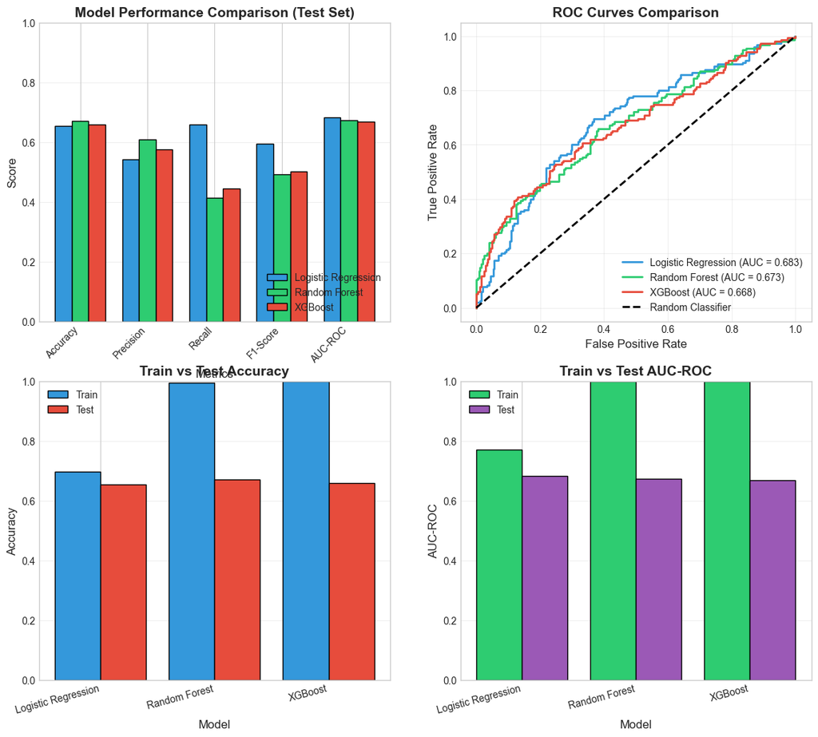

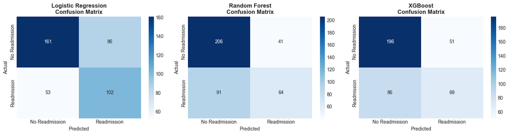

```python
# Create a comprehensive comparison visualization
fig, axes = plt.subplots(2, 2, figsize=(14, 12))

# 1. Bar plot comparing test metrics
ax1 = axes[0, 0]
x = np.arange(len(test_metrics.columns))
width = 0.25
colors = ['#3498db', '#2ecc71', '#e74c3c']

for i, (model, color) in enumerate(zip(test_metrics.index, colors)):
    ax1.bar(x + i*width, test_metrics.loc[model], width, label=model, color=color, edgecolor='black')

ax1.set_xlabel('Metrics', fontsize=12)
ax1.set_ylabel('Score', fontsize=12)
ax1.set_title('Model Performance Comparison (Test Set)', fontsize=14, fontweight='bold')
ax1.set_xticks(x + width)
ax1.set_xticklabels(test_metrics.columns, rotation=45, ha='right')
ax1.legend(loc='lower right')
ax1.set_ylim(0, 1)
ax1.grid(axis='y', alpha=0.3)

# 2. ROC Curves comparison
ax2 = axes[0, 1]
plot_roc_curve(y_test, lr_prob, 'Logistic Regression', ax2, '#3498db')
plot_roc_curve(y_test, rf_prob, 'Random Forest', ax2, '#2ecc71')
plot_roc_curve(y_test, xgb_prob, 'XGBoost', ax2, '#e74c3c')
ax2.plot([0, 1], [0, 1], 'k--', lw=2, label='Random Classifier')
ax2.set_xlabel('False Positive Rate', fontsize=12)
ax2.set_ylabel('True Positive Rate', fontsize=12)
ax2.set_title('ROC Curves Comparison', fontsize=14, fontweight='bold')
ax2.legend(loc='lower right')
ax2.grid(alpha=0.3)

# 3. Confusion Matrices
ax3 = axes[1, 0]
ax4 = axes[1, 1]

# Create a combined confusion matrix subplot
fig2, axes2 = plt.subplots(1, 3, figsize=(15, 4))
plot_confusion_matrix(y_test, lr_pred, 'Logistic Regression', axes2[0])
plot_confusion_matrix(y_test, rf_pred, 'Random Forest', axes2[1])
plot_confusion_matrix(y_test, xgb_pred, 'XGBoost', axes2[2])

# For the main figure, show Train vs Test comparison
train_metrics = all_metrics[['Train Accuracy', 'Train Precision', 'Train Recall', 'Train F1', 'Train AUC-ROC']]
train_metrics.columns = ['Accuracy', 'Precision', 'Recall', 'F1-Score', 'AUC-ROC']

# Train vs Test Accuracy comparison
metrics_comparison = pd.DataFrame({
    'Model': ['Logistic Regression', 'Random Forest', 'XGBoost'],
    'Train': train_metrics['Accuracy'].values,
    'Test': test_metrics['Accuracy'].values
})
x_pos = np.arange(len(metrics_comparison))
ax3.bar(x_pos - 0.2, metrics_comparison['Train'], 0.4, label='Train', color='#3498db', edgecolor='black')
ax3.bar(x_pos + 0.2, metrics_comparison['Test'], 0.4, label='Test', color='#e74c3c', edgecolor='black')
ax3.set_xlabel('Model', fontsize=12)
ax3.set_ylabel('Accuracy', fontsize=12)
ax3.set_title('Train vs Test Accuracy', fontsize=14, fontweight='bold')
ax3.set_xticks(x_pos)
ax3.set_xticklabels(metrics_comparison['Model'], rotation=15, ha='right')
ax3.legend()
ax3.set_ylim(0, 1)
ax3.grid(axis='y', alpha=0.3)

# AUC-ROC comparison
auc_comparison = pd.DataFrame({
    'Model': ['Logistic Regression', 'Random Forest', 'XGBoost'],
    'Train': train_metrics['AUC-ROC'].values,
    'Test': test_metrics['AUC-ROC'].values
})
ax4.bar(x_pos - 0.2, auc_comparison['Train'], 0.4, label='Train', color='#2ecc71', edgecolor='black')
ax4.bar(x_pos + 0.2, auc_comparison['Test'], 0.4, label='Test', color='#9b59b6', edgecolor='black')
ax4.set_xlabel('Model', fontsize=12)
ax4.set_ylabel('AUC-ROC', fontsize=12)
ax4.set_title('Train vs Test AUC-ROC', fontsize=14, fontweight='bold')
ax4.set_xticks(x_pos)
ax4.set_xticklabels(auc_comparison['Model'], rotation=15, ha='right')
ax4.legend()
ax4.set_ylim(0, 1)
ax4.grid(axis='y', alpha=0.3)

plt.tight_layout()
plt.show()
fig2.tight_layout()
plt.show()
```

### 5.3 Feature Importance Analysis

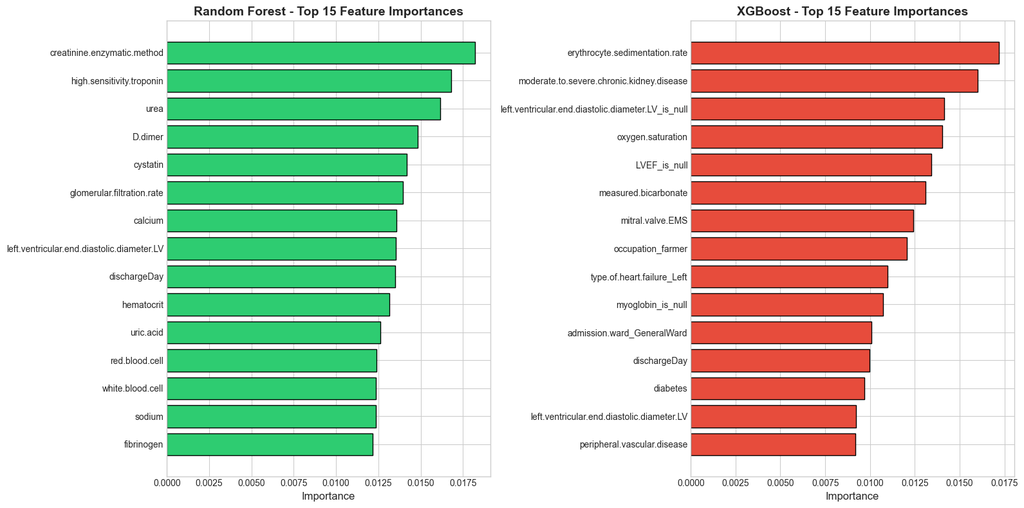

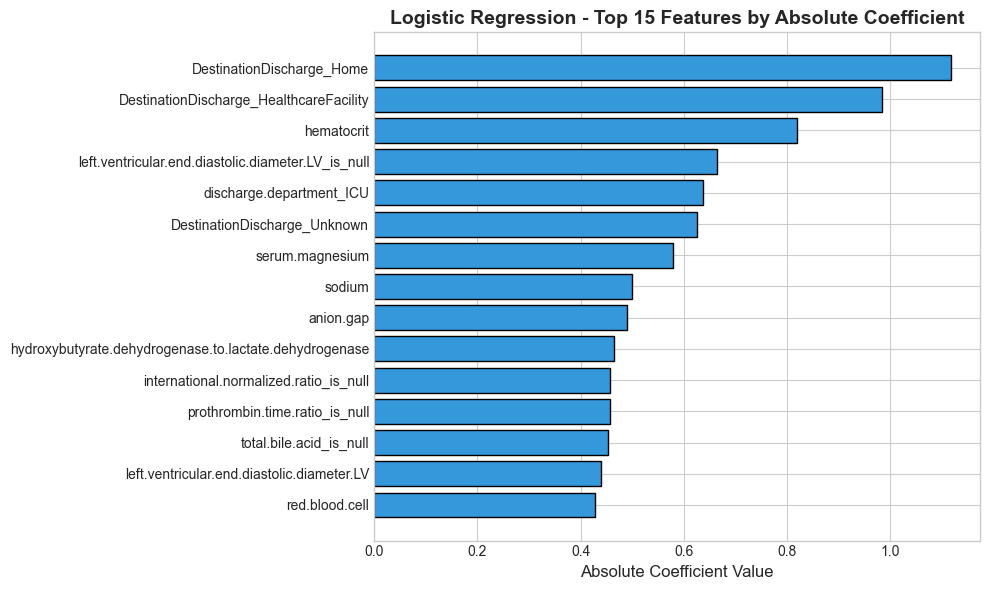

```python
# Feature importance comparison between Random Forest and XGBoost
fig, axes = plt.subplots(1, 2, figsize=(16, 8))

# Random Forest Feature Importance
rf_importance = pd.DataFrame({
    'Feature': X_train.columns,
    'Importance': rf_model.feature_importances_
}).sort_values('Importance', ascending=False).head(15)

axes[0].barh(range(len(rf_importance)), rf_importance['Importance'], color='#2ecc71', edgecolor='black')
axes[0].set_yticks(range(len(rf_importance)))
axes[0].set_yticklabels(rf_importance['Feature'])
axes[0].set_xlabel('Importance', fontsize=12)
axes[0].set_title('Random Forest - Top 15 Feature Importances', fontsize=14, fontweight='bold')
axes[0].invert_yaxis()

# XGBoost Feature Importance
xgb_importance = pd.DataFrame({
    'Feature': X_train.columns,
    'Importance': xgb_model.feature_importances_
}).sort_values('Importance', ascending=False).head(15)

axes[1].barh(range(len(xgb_importance)), xgb_importance['Importance'], color='#e74c3c', edgecolor='black')
axes[1].set_yticks(range(len(xgb_importance)))
axes[1].set_yticklabels(xgb_importance['Feature'])
axes[1].set_xlabel('Importance', fontsize=12)
axes[1].set_title('XGBoost - Top 15 Feature Importances', fontsize=14, fontweight='bold')
axes[1].invert_yaxis()

plt.tight_layout()
plt.show()

# Logistic Regression Coefficients
lr_coef = pd.DataFrame({
    'Feature': X_train.columns,
    'Coefficient': np.abs(lr_model.coef_[0])
}).sort_values('Coefficient', ascending=False).head(15)

fig, ax = plt.subplots(figsize=(10, 6))
ax.barh(range(len(lr_coef)), lr_coef['Coefficient'], color='#3498db', edgecolor='black')
ax.set_yticks(range(len(lr_coef)))
ax.set_yticklabels(lr_coef['Feature'])
ax.set_xlabel('Absolute Coefficient Value', fontsize=12)
ax.set_title('Logistic Regression - Top 15 Features by Absolute Coefficient', fontsize=14, fontweight='bold')
ax.invert_yaxis()
plt.tight_layout()
plt.show()
```

### 5.4 Cross-Validation Comparison

```
============================================================
CROSS-VALIDATION COMPARISON (5-Fold Stratified)
============================================================

Cross-Validation Results:
              Model  Mean AUC-ROC  Std AUC-ROC  Min AUC-ROC  Max AUC-ROC
Logistic Regression      0.618250     0.015782     0.606886     0.649542
      Random Forest      0.635926     0.034254     0.600581     0.699771
            XGBoost      0.630183     0.028887     0.593090     0.674431
```

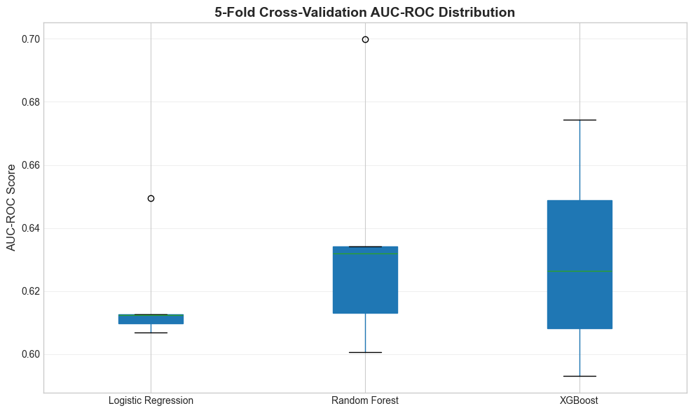

```python
# Perform detailed cross-validation for all models
print("=" * 60)
print("CROSS-VALIDATION COMPARISON (5-Fold Stratified)")
print("=" * 60)

# Define cross-validation strategy
cv = StratifiedKFold(n_splits=5, shuffle=True, random_state=42)

# Store CV results
cv_results = {}

# Logistic Regression CV
lr_cv = cross_val_score(lr_model, X_train_scaled, y_train, cv=cv, scoring='roc_auc')
cv_results['Logistic Regression'] = lr_cv

# Random Forest CV
rf_cv = cross_val_score(rf_model, X_train, y_train, cv=cv, scoring='roc_auc')
cv_results['Random Forest'] = rf_cv

# XGBoost CV
xgb_cv = cross_val_score(xgb_model, X_train, y_train, cv=cv, scoring='roc_auc')
cv_results['XGBoost'] = xgb_cv

# Display results
cv_summary = pd.DataFrame({
    'Model': list(cv_results.keys()),
    'Mean AUC-ROC': [np.mean(scores) for scores in cv_results.values()],
    'Std AUC-ROC': [np.std(scores) for scores in cv_results.values()],
    'Min AUC-ROC': [np.min(scores) for scores in cv_results.values()],
    'Max AUC-ROC': [np.max(scores) for scores in cv_results.values()]
})
print("\nCross-Validation Results:")
print(cv_summary.to_string(index=False))

# Visualize CV results
fig, ax = plt.subplots(figsize=(10, 6))
cv_df = pd.DataFrame(cv_results)
cv_df.boxplot(ax=ax, patch_artist=True)
ax.set_ylabel('AUC-ROC Score', fontsize=12)
ax.set_title('5-Fold Cross-Validation AUC-ROC Distribution', fontsize=14, fontweight='bold')
ax.grid(axis='y', alpha=0.3)
plt.tight_layout()
plt.show()
```

## 6. Summary and Conclusion

```python
# Final Summary Table
print("=" * 80)
print("FINAL MODEL COMPARISON SUMMARY")
print("=" * 80)

# Create comprehensive summary
summary_df = pd.DataFrame({
    'Metric': ['Test Accuracy', 'Test Precision', 'Test Recall', 'Test F1-Score',
               'Test AUC-ROC', 'CV Mean AUC-ROC', 'CV Std AUC-ROC'],
    'Logistic Regression': [
        f"{lr_metrics['Test Accuracy']:.4f}",
        f"{lr_metrics['Test Precision']:.4f}",
        f"{lr_metrics['Test Recall']:.4f}",
        f"{lr_metrics['Test F1']:.4f}",
        f"{lr_metrics['Test AUC-ROC']:.4f}",
        f"{np.mean(cv_results['Logistic Regression']):.4f}",
        f"{np.std(cv_results['Logistic Regression']):.4f}"
    ],
    'Random Forest': [
        f"{rf_metrics['Test Accuracy']:.4f}",
        f"{rf_metrics['Test Precision']:.4f}",
        f"{rf_metrics['Test Recall']:.4f}",
        f"{rf_metrics['Test F1']:.4f}",
        f"{rf_metrics['Test AUC-ROC']:.4f}",
        f"{np.mean(cv_results['Random Forest']):.4f}",
        f"{np.std(cv_results['Random Forest']):.4f}"
    ],
    'XGBoost': [
        f"{xgb_metrics['Test Accuracy']:.4f}",
        f"{xgb_metrics['Test Precision']:.4f}",
        f"{xgb_metrics['Test Recall']:.4f}",
        f"{xgb_metrics['Test F1']:.4f}",
        f"{xgb_metrics['Test AUC-ROC']:.4f}",
        f"{np.mean(cv_results['XGBoost']):.4f}",
        f"{np.std(cv_results['XGBoost']):.4f}"
    ]
})

print("\n" + summary_df.to_string(index=False))

# Determine best model
test_auc_scores = {
    'Logistic Regression': lr_metrics['Test AUC-ROC'],
    'Random Forest': rf_metrics['Test AUC-ROC'],
    'XGBoost': xgb_metrics['Test AUC-ROC']
}
best_model = max(test_auc_scores, key=test_auc_scores.get)

print("\n" + "=" * 80)
print(f"BEST PERFORMING MODEL (based on Test AUC-ROC): {best_model}")
print(f"AUC-ROC Score: {test_auc_scores[best_model]:.4f}")
print("=" * 80)
```

```
================================================================================
FINAL MODEL COMPARISON SUMMARY
================================================================================

         Metric Logistic Regression Random Forest XGBoost
  Test Accuracy              0.6542        0.6716  0.6592
 Test Precision              0.5426        0.6095  0.5750
    Test Recall              0.6581        0.4129  0.4452
  Test F1-Score              0.5948        0.4923  0.5018
   Test AUC-ROC              0.6829        0.6729  0.6681
CV Mean AUC-ROC              0.6182        0.6359  0.6302
 CV Std AUC-ROC              0.0158        0.0343  0.0289

================================================================================
BEST PERFORMING MODEL (based on Test AUC-ROC): Logistic Regression
AUC-ROC Score: 0.6829
================================================================================
```

### Key Findings

1. **Data Preprocessing:**
   - **Important Insight:** Null values in this medical dataset are not "missing" but rather meaningful deliberate nulls (e.g., a null lab test value indicates the test was not performed, which itself is clinically significant)
   - Binary indicator features were created to preserve the information that a value was null
   - Categorical variables were encoded using Label Encoding and One-Hot Encoding
   - Features were scaled for Logistic Regression while tree-based models used unscaled data
   - Class imbalance was addressed using class weights and scale_pos_weight parameters
2. **Model Comparison:**
   - All three models were trained and evaluated on predicting emergency department readmission within 6 months
   - Performance was assessed using multiple metrics: Accuracy, Precision, Recall, F1-Score, and AUC-ROC
   - Cross-validation was performed to assess model stability
3. **Clinical Relevance:**
   - For healthcare applications, **Recall** is particularly important as we want to identify as many at-risk patients as possible
   - **AUC-ROC** provides a comprehensive view of model performance across different thresholds
   - Feature importance analysis reveals which clinical factors are most predictive of readmission
   - The null indicator features may reveal patterns about which tests are typically ordered for high-risk patients
4. **Recommendations:**
   - The best performing model should be selected based on the specific clinical requirements
   - Further hyperparameter tuning could improve model performance
   - Additional feature engineering using domain knowledge may enhance predictions